# R for Reproducible Scientific Analysis

18 January 2017

```r
library(tidyverse)
library(gapminder)
```

# Dataframe manipulation with `tidyr`

Researchers often want to manipulate their data from the ‘wide’ to the ‘long’ format, or *vice versa*.

In the ‘long’ format, you usually have single column for the observed values, one column recording the name of the variable measured and the other columns are ID variables. In this format observations from 1 subject go into multiple lines (rows).

For the ‘wide’ format each row is often a id’ed site/subject/patient and you have multiple observation variables containing the same type of data. These can be either repeated observations over time, or observation of multiple variables (or a mix of both). You may find data input may be simpler or some other applications may prefer the ‘wide’ format. In this format observations from 1 subject get recorded into a single line (row).

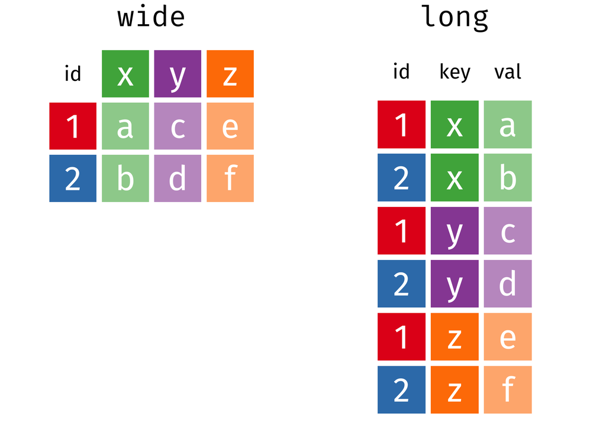

tidyexplain-wide-long

These data formats mainly affect readability. For humans, the wide format is often more intuitive since we can often see more of the data on the screen due to it’s shape. However, the long format is more machine readable and is closer to the formatting of databases. The ID variables in our dataframes are similar to the fields in a database and observed variables are like the database values.This tutorial will help you efficiently transform your data regardless of original format.

## Getting started

First, lets look at the structure of our original `gapminder` dataframe:

```r
gapminder
```

```
## # A tibble: 1,704 x 6
##    country     continent  year lifeExp      pop gdpPercap
##    <fct>       <fct>     <int>   <dbl>    <int>     <dbl>
##  1 Afghanistan Asia       1952    28.8  8425333      779.
##  2 Afghanistan Asia       1957    30.3  9240934      821.
##  3 Afghanistan Asia       1962    32.0 10267083      853.
##  4 Afghanistan Asia       1967    34.0 11537966      836.
##  5 Afghanistan Asia       1972    36.1 13079460      740.
##  6 Afghanistan Asia       1977    38.4 14880372      786.
##  7 Afghanistan Asia       1982    39.9 12881816      978.
##  8 Afghanistan Asia       1987    40.8 13867957      852.
##  9 Afghanistan Asia       1992    41.7 16317921      649.
## 10 Afghanistan Asia       1997    41.8 22227415      635.
## # … with 1,694 more rows
```

## **Challenge 1.**

### Assignment

> - Is `gapminder` dataset presented in a purely long, purely wide, or some intermediate format?

### Solution

The original `gapminder` data frame is in an intermediate format. It is not purely long since it had multiple observation variables (`pop`, `lifeExp`, `gdpPercap`).

## Tidy data format

Hadley Wickham proposed definition of “tidy data” in his famous paper. The following are the principles behind good data organization:

1. Each variable must have its own column.
2. Each observation must have its own row.
3. Each value must have its own cell.

Sometimes, as with the `gapminder` dataset, we have multiple types of observed data. It is somewhere in between the purely ‘long’ and ‘wide’ data formats. We have 3 “ID variables” (`continent`, `country`, `year`) and 3 “value variables” (`pop`, `lifeExp`, `gdpPercap`) corresponding to 3 types of data we observe. It is usually preferred format in most cases despite not having ALL observations in 1 column given that all 3 observation variables have different units (and most importantly data types). There are few operations that would need us to stretch out this dataframe any longer (*i.e.* 3 ID variables, 1 key variable and 1 value variable).

While using many of the functions in R, which are often vector-based, you usually do not want to do mathematical operations on values in different units. For example, using the purely long format, a single mean for all of the values of population, life expectancy, and GDP would not be meaningful since it would return the mean of values with 3 incompatible units. The solution is that we first manipulate the data either by grouping (see the lesson on dplyr), or we change the structure of the dataframe. **Note**: Some plotting functions in R actually work better in the ‘long’ data format.

## Reading in a data set caught “in a wild” with `readxl`

Until now, we’ve been using the nicely formatted original gapminder dataset, but ‘real’ data (*e.g.* our own research data) is rarely so well organized.

We will now download two additional files from the [gapminder](https://www.gapminder.org) website. Go to “Data” and search for “Children per woman (total fertility)”. Download the Excel file (“indicator undata total_fertility.xlsx”) into a new sub-folder in your Rstudio project called “data_raw”.

To read in the new Excel file and take a look at its structure, we need to load a additional package. `readxl` is part of the `tidyverse` package collection, but needs to be called independently.

```r
library(readxl)
raw_fert <- read_excel(path = "data_raw/children_per_woman_total_fertility.xlsx")
raw_fert
```

```
## # A tibble: 184 x 220
##    country `1800` `1801` `1802` `1803` `1804` `1805` `1806` `1807` `1808`
##    <chr>    <dbl>  <dbl>  <dbl>  <dbl>  <dbl>  <dbl>  <dbl>  <dbl>  <dbl>
##  1 Afghan…   7      7      7      7      7      7      7      7      7
##  2 Albania   4.6    4.6    4.6    4.6    4.6    4.6    4.6    4.6    4.6
##  3 Algeria   6.99   6.99   6.99   6.99   6.99   6.99   6.99   6.99   6.99
##  4 Angola    6.93   6.93   6.93   6.93   6.93   6.93   6.93   6.94   6.94
##  5 Antigu…   5      5      4.99   4.99   4.99   4.98   4.98   4.97   4.97
##  6 Argent…   6.8    6.8    6.8    6.8    6.8    6.8    6.8    6.8    6.8
##  7 Armenia   7.8    7.8    7.81   7.81   7.81   7.82   7.82   7.82   7.83
##  8 Austra…   6.5    6.48   6.46   6.44   6.42   6.4    6.38   6.36   6.34
##  9 Austria   5.1    5.1    5.1    5.1    5.1    5.1    5.1    5.1    5.1
## 10 Azerba…   8.1    8.1    8.1    8.1    8.1    8.1    8.1    8.1    8.1
## # … with 174 more rows, and 210 more variables: `1809` <dbl>,
## #   `1810` <dbl>, `1811` <dbl>, `1812` <dbl>, `1813` <dbl>, `1814` <dbl>,
## #   `1815` <dbl>, `1816` <dbl>, `1817` <dbl>, `1818` <dbl>, `1819` <dbl>,
## #   `1820` <dbl>, `1821` <dbl>, `1822` <dbl>, `1823` <dbl>, `1824` <dbl>,
## #   `1825` <dbl>, `1826` <dbl>, `1827` <dbl>, `1828` <dbl>, `1829` <dbl>,
## #   `1830` <dbl>, `1831` <dbl>, `1832` <dbl>, `1833` <dbl>, `1834` <dbl>,
## #   `1835` <dbl>, `1836` <dbl>, `1837` <dbl>, `1838` <dbl>, `1839` <dbl>,
## #   `1840` <dbl>, `1841` <dbl>, `1842` <dbl>, `1843` <dbl>, `1844` <dbl>,
## #   `1845` <dbl>, `1846` <dbl>, `1847` <dbl>, `1848` <dbl>, `1849` <dbl>,
## #   `1850` <dbl>, `1851` <dbl>, `1852` <dbl>, `1853` <dbl>, `1854` <dbl>,
## #   `1855` <dbl>, `1856` <dbl>, `1857` <dbl>, `1858` <dbl>, `1859` <dbl>,
## #   `1860` <dbl>, `1861` <dbl>, `1862` <dbl>, `1863` <dbl>, `1864` <dbl>,
## #   `1865` <dbl>, `1866` <dbl>, `1867` <dbl>, `1868` <dbl>, `1869` <dbl>,
## #   `1870` <dbl>, `1871` <dbl>, `1872` <dbl>, `1873` <dbl>, `1874` <dbl>,
## #   `1875` <dbl>, `1876` <dbl>, `1877` <dbl>, `1878` <dbl>, `1879` <dbl>,
## #   `1880` <dbl>, `1881` <dbl>, `1882` <dbl>, `1883` <dbl>, `1884` <dbl>,
## #   `1885` <dbl>, `1886` <dbl>, `1887` <dbl>, `1888` <dbl>, `1889` <dbl>,
## #   `1890` <dbl>, `1891` <dbl>, `1892` <dbl>, `1893` <dbl>, `1894` <dbl>,
## #   `1895` <dbl>, `1896` <dbl>, `1897` <dbl>, `1898` <dbl>, `1899` <dbl>,
## #   `1900` <dbl>, `1901` <dbl>, `1902` <dbl>, `1903` <dbl>, `1904` <dbl>,
## #   `1905` <dbl>, `1906` <dbl>, `1907` <dbl>, `1908` <dbl>, …
```

In this spreadsheet, you might observe that values of total fetility are spread by year (horizontally) for every country(vertically). What we ideally need is to have country and year as identifiers and fertility as a single observational (value) column.

## From wide to long format with `pivot_longer()`

The first step towards getting our nice intermediate data format is to first convert from the wide to the long format. The `tidyr` newly added function `pivot_longer()` will ‘gather’ your observations into a single variable.

```r
fert <- raw_fert %>%
  pivot_longer(-country, names_to = "year", values_to = "fert") %>%
  mutate(year = as.integer(year))
fert
```

```
## # A tibble: 40,296 x 3
##    country      year  fert
##    <chr>       <int> <dbl>
##  1 Afghanistan  1800     7
##  2 Afghanistan  1801     7
##  3 Afghanistan  1802     7
##  4 Afghanistan  1803     7
##  5 Afghanistan  1804     7
##  6 Afghanistan  1805     7
##  7 Afghanistan  1806     7
##  8 Afghanistan  1807     7
##  9 Afghanistan  1808     7
## 10 Afghanistan  1809     7
## # … with 40,286 more rows
```

We can use this data directly and visualize it!

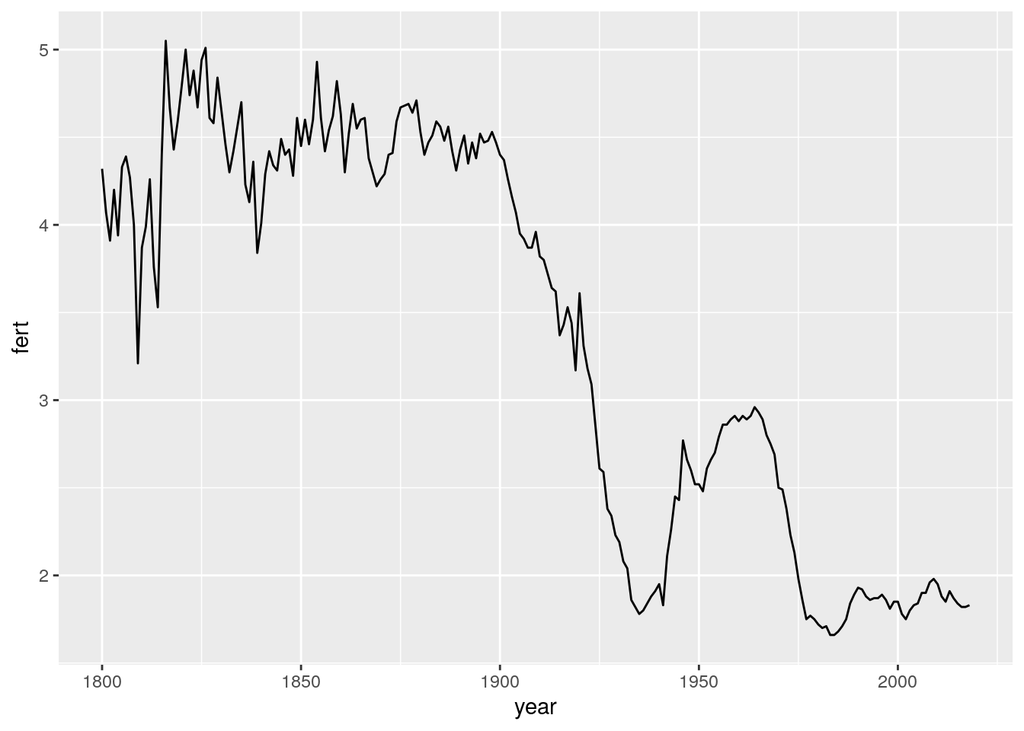

```r
fert %>%
  filter(country == "Norway") %>%
  ggplot() +
  geom_line(mapping = aes(x = year, y = fert))
```

## **Challenge 2.**

### Assignment

> - What was the average infant mortality in Norway during this millennium? **Hint**: Download the Excel file for “Infant mortality (rate per 1,000 births)” from the [gapminder](https://www.gapminder.org) website.

### Solution

```r
raw_infantMort <- read_excel(path = "data_raw/infant_mortality_rate_per_1000_births.xlsx")

infantMort <- raw_infantMort %>%
  pivot_longer(-country, names_to = "year", values_to = "infantMort") %>%
  mutate(year = as.integer(year)) %>%
  mutate(infantMort = as.numeric(infantMort))

infantMort %>%
  filter(country == "Norway") %>%
  filter(year >= 2000) %>%
  summarize(mean_infantMort = mean(infantMort))
```

```
## # A tibble: 1 x 1
##   mean_infantMort
##             <dbl>
## 1            2.94
```

## Using `join()` to add new information to existing data sets

In a situation like this, we would ideally incorporate our newly harvested data into the existing ``gapminder data set.`dplyr`offers a powerful functional family called`join()`, which helps in merging two data sets on conditional parameters. The functionality of the different`join()` functions is best explained by trying them out:

```r
gapminder
```

```
## # A tibble: 1,704 x 6
##    country     continent  year lifeExp      pop gdpPercap
##    <fct>       <fct>     <int>   <dbl>    <int>     <dbl>
##  1 Afghanistan Asia       1952    28.8  8425333      779.
##  2 Afghanistan Asia       1957    30.3  9240934      821.
##  3 Afghanistan Asia       1962    32.0 10267083      853.
##  4 Afghanistan Asia       1967    34.0 11537966      836.
##  5 Afghanistan Asia       1972    36.1 13079460      740.
##  6 Afghanistan Asia       1977    38.4 14880372      786.
##  7 Afghanistan Asia       1982    39.9 12881816      978.
##  8 Afghanistan Asia       1987    40.8 13867957      852.
##  9 Afghanistan Asia       1992    41.7 16317921      649.
## 10 Afghanistan Asia       1997    41.8 22227415      635.
## # … with 1,694 more rows
```

```r
gapminder %>%
  inner_join(fert, by = c("year", "country"))
```

```
## # A tibble: 1,608 x 7
##    country     continent  year lifeExp      pop gdpPercap  fert
##    <chr>       <fct>     <int>   <dbl>    <int>     <dbl> <dbl>
##  1 Afghanistan Asia       1952    28.8  8425333      779.  7.55
##  2 Afghanistan Asia       1957    30.3  9240934      821.  7.49
##  3 Afghanistan Asia       1962    32.0 10267083      853.  7.45
##  4 Afghanistan Asia       1967    34.0 11537966      836.  7.45
##  5 Afghanistan Asia       1972    36.1 13079460      740.  7.45
##  6 Afghanistan Asia       1977    38.4 14880372      786.  7.45
##  7 Afghanistan Asia       1982    39.9 12881816      978.  7.45
##  8 Afghanistan Asia       1987    40.8 13867957      852.  7.46
##  9 Afghanistan Asia       1992    41.7 16317921      649.  7.5
## 10 Afghanistan Asia       1997    41.8 22227415      635.  7.64
## # … with 1,598 more rows
```

```r
gapminder %>%
  left_join(fert, by = c("year", "country"))
```

```
## # A tibble: 1,704 x 7
##    country     continent  year lifeExp      pop gdpPercap  fert
##    <chr>       <fct>     <int>   <dbl>    <int>     <dbl> <dbl>
##  1 Afghanistan Asia       1952    28.8  8425333      779.  7.55
##  2 Afghanistan Asia       1957    30.3  9240934      821.  7.49
##  3 Afghanistan Asia       1962    32.0 10267083      853.  7.45
##  4 Afghanistan Asia       1967    34.0 11537966      836.  7.45
##  5 Afghanistan Asia       1972    36.1 13079460      740.  7.45
##  6 Afghanistan Asia       1977    38.4 14880372      786.  7.45
##  7 Afghanistan Asia       1982    39.9 12881816      978.  7.45
##  8 Afghanistan Asia       1987    40.8 13867957      852.  7.46
##  9 Afghanistan Asia       1992    41.7 16317921      649.  7.5
## 10 Afghanistan Asia       1997    41.8 22227415      635.  7.64
## # … with 1,694 more rows
```

```r
gapminder %>%
  right_join(fert, by = c("year", "country"))
```

```
## # A tibble: 40,296 x 7
##    country     continent  year lifeExp   pop gdpPercap  fert
##    <chr>       <fct>     <int>   <dbl> <int>     <dbl> <dbl>
##  1 Afghanistan <NA>       1800      NA    NA        NA     7
##  2 Afghanistan <NA>       1801      NA    NA        NA     7
##  3 Afghanistan <NA>       1802      NA    NA        NA     7
##  4 Afghanistan <NA>       1803      NA    NA        NA     7
##  5 Afghanistan <NA>       1804      NA    NA        NA     7
##  6 Afghanistan <NA>       1805      NA    NA        NA     7
##  7 Afghanistan <NA>       1806      NA    NA        NA     7
##  8 Afghanistan <NA>       1807      NA    NA        NA     7
##  9 Afghanistan <NA>       1808      NA    NA        NA     7
## 10 Afghanistan <NA>       1809      NA    NA        NA     7
## # … with 40,286 more rows
```

```r
gapminder %>%
  full_join(fert, by = c("year", "country"))
```

```
## # A tibble: 40,392 x 7
##    country     continent  year lifeExp      pop gdpPercap  fert
##    <chr>       <fct>     <int>   <dbl>    <int>     <dbl> <dbl>
##  1 Afghanistan Asia       1952    28.8  8425333      779.  7.55
##  2 Afghanistan Asia       1957    30.3  9240934      821.  7.49
##  3 Afghanistan Asia       1962    32.0 10267083      853.  7.45
##  4 Afghanistan Asia       1967    34.0 11537966      836.  7.45
##  5 Afghanistan Asia       1972    36.1 13079460      740.  7.45
##  6 Afghanistan Asia       1977    38.4 14880372      786.  7.45
##  7 Afghanistan Asia       1982    39.9 12881816      978.  7.45
##  8 Afghanistan Asia       1987    40.8 13867957      852.  7.46
##  9 Afghanistan Asia       1992    41.7 16317921      649.  7.5
## 10 Afghanistan Asia       1997    41.8 22227415      635.  7.64
## # … with 40,382 more rows
```

```r
gapminder_plus <- gapminder %>%
  left_join(fert, by = c("year", "country"))
```

[Tidyexplain](https://github.com/gadenbuie/tidyexplain) is a repository of animations illustrating among other things also various types of joins.

We want to stick as close to the original `gapminder` data set as possible, so `left_join()` is the option of choice

```r
gapminder_plus <- gapminder %>%
  left_join(fert, by = c("year", "country"))
gapminder_plus
```

```
## # A tibble: 1,704 x 7
##    country     continent  year lifeExp      pop gdpPercap  fert
##    <chr>       <fct>     <int>   <dbl>    <int>     <dbl> <dbl>
##  1 Afghanistan Asia       1952    28.8  8425333      779.  7.55
##  2 Afghanistan Asia       1957    30.3  9240934      821.  7.49
##  3 Afghanistan Asia       1962    32.0 10267083      853.  7.45
##  4 Afghanistan Asia       1967    34.0 11537966      836.  7.45
##  5 Afghanistan Asia       1972    36.1 13079460      740.  7.45
##  6 Afghanistan Asia       1977    38.4 14880372      786.  7.45
##  7 Afghanistan Asia       1982    39.9 12881816      978.  7.45
##  8 Afghanistan Asia       1987    40.8 13867957      852.  7.46
##  9 Afghanistan Asia       1992    41.7 16317921      649.  7.5
## 10 Afghanistan Asia       1997    41.8 22227415      635.  7.64
## # … with 1,694 more rows
```

At this point it is advisable to check for “holes” in the data, i.e., missing values. This can have implications for later treatment of the data.

```r
gapminder_plus %>%
  is.na() %>%
  colSums()
```

```
##   country continent      year   lifeExp       pop gdpPercap      fert
##         0         0         0         0         0         0        96
```

## **Challenge 3.**

### Assignment

> - What are the average fertility and average infant mortality of the `gapminder` continents?

### Solution

```r
gapminder_plus <- gapminder %>%
  left_join(fert, by = c("year", "country")) %>%
  left_join(infantMort, by = c("year", "country"))
colSums(is.na(gapminder_plus))
```

```
##    country  continent       year    lifeExp        pop  gdpPercap
##          0          0          0          0          0          0
##       fert infantMort
##         96        304
```

```r
gapminder_plus_summary <- gapminder_plus %>%
  group_by(continent) %>%
  summarize(mean_fert = mean(fert),
            mean_infantMort = mean(infantMort))
gapminder_plus_summary
```

```
## # A tibble: 5 x 3
##   continent mean_fert mean_infantMort
##   <fct>         <dbl>           <dbl>
## 1 Africa        NA               NA
## 2 Americas      NA               NA
## 3 Asia          NA               NA
## 4 Europe         2.27            NA
## 5 Oceania        2.50            13.4
```

```r
gapminder_plus_summary <- gapminder_plus %>%
  group_by(continent) %>%
  summarize(mean_fert = mean(fert, na.rm = TRUE),
            mean_infantMort = mean(infantMort, na.rm = TRUE))
gapminder_plus_summary
```

```
## # A tibble: 5 x 3
##   continent mean_fert mean_infantMort
##   <fct>         <dbl>           <dbl>
## 1 Africa         6.18           107.
## 2 Americas       4.29            56.2
## 3 Asia           4.91            69.5
## 4 Europe         2.27            22.8
## 5 Oceania        2.50            13.4
```

## Visualizing on the map

For the final act, we will use the existing `gapminder` data, include information on fertility and child mortality, and visualize them on a map. We can merge this data with out own, by ensuring the map data has a *common variables* as our statistics data file from gapminder. In this case, our world map has a column called `name` that corresponds with a column in the gapminder data called `country`, so we just indicate this in the `by` argument and merge the two data sets together. We can then plot different aesthetics on the map, based on the data from gampinder.

```r
# install.packages("rnaturalearth")
library(sf)
world_map <- rnaturalearth::ne_countries(returnclass = "sf")
```

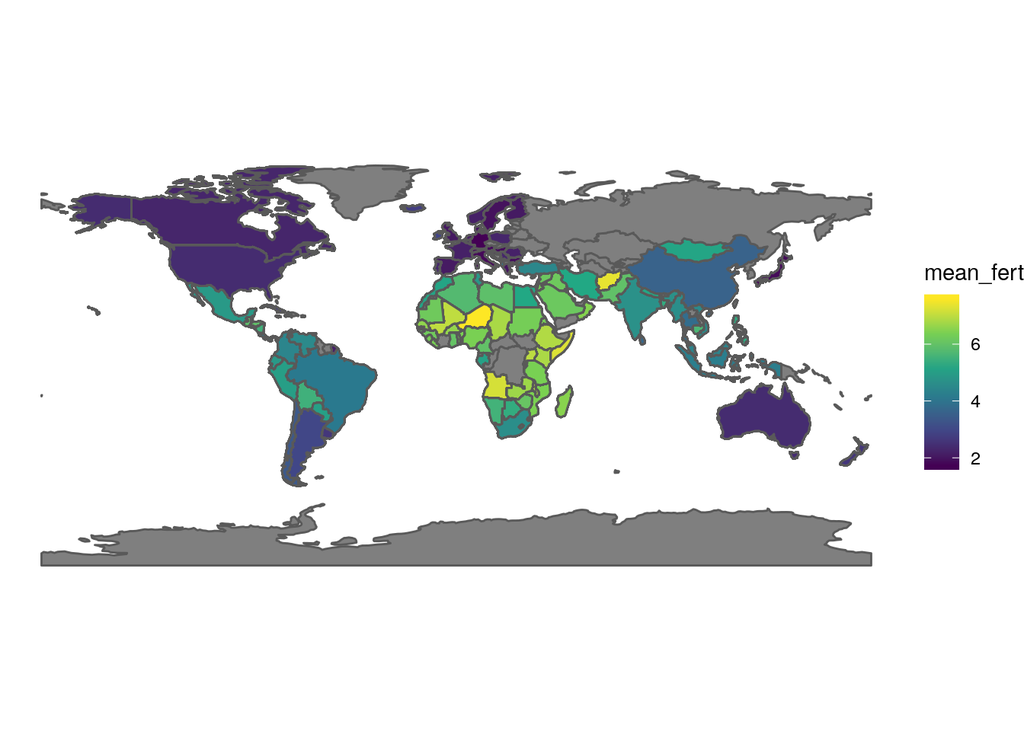

```r
gapminder_map <- gapminder_plus %>%
  group_by(country) %>%
  mutate(mean_fert=mean(fert)) %>%
  right_join(world_map, by=c("country"="name"))

ggplot(gapminder_map) +
  geom_sf(aes(fill = mean_fert, geometry=geometry))+
  scale_fill_viridis_c()+
  theme_void()+
  coord_sf()
```

Note that “grey” countries are not part of `gapminder` or appear under a different name and hence only appear as `NA`’s.

## Save the new `gapminder_plus`

As we will need it later today, please safe a copy of the new `gapminder_plus`:

```r
write_csv(gapminder_plus, path = "data/gapminder_plus.csv")
```

# Key Points

- Use the `tidyr` package to change the layout of dataframes.
- Use `pivot_longer()` to go from wide to long format.
- Use `join()` to include new data in an already existing data set.
- Use `write_csv()` to safe data tidied up during the session.